# R notebook

# Intro

In this notebooks, we will go through

- Examine the quantification of pseudogenes,in term of total read counts in pseudogenes vs total counts in all annotations.

# Overlapping geneIDs

## paring annotations

Load gtf files

```r
library(rtracklayer)
library(ggplot2)
library(plyr)
library(reshape2)
library(plotly)
library(VennDiagram)
require(gplots)
system.time(gtf_gencode_comp <- readGFF("~/Documents/HCA/reference/refs/gencode.v27.chr_patch_hapl_scaff.annotation.gtf", version=2L, tags = c("gene_name","gene_id", "transcript_id","gene_type")))
```

```
   user  system elapsed
 16.826   1.089  18.139
```

```r
system.time(gtf_gencode_basic <- readGFF("~/Documents/HCA/reference/refs/gencode.v27.chr_patch_hapl_scaff.basic.annotation.gtf", version=2L, tags = c("gene_name","gene_id", "transcript_id","gene_type")))
```

```
   user  system elapsed
  8.715   0.574   9.345
```

```r
system.time(gtf_ensembl <- readGFF("~/Documents/HCA/reference/refs/Homo_sapiens.GRCh38.90.gtf", version=2L,tags = c("gene_name","gene_id", "transcript_id","gene_biotype")))
```

```
   user  system elapsed
 13.704   0.864  14.658
```

```r
system.time(gtf_refseq <- readGFF("~/Documents/HCA/reference/refs/ncbi-genomes-2017-10-05/GCF_000001405.37_GRCh38.p11_genomic.gff.gz", tags = c("ID", "Name","gbkey","gene","gene_biotype","Parent")))
```

```
   user  system elapsed
 21.874   0.768  22.678
```

```r
g4<-unique(gtf_gencode_basic$gene_name)
g3<-unique(gtf_gencode_comp$gene_name)
g2<-unique(gtf_ensembl$gene_name)
g1<-unique(na.omit(gtf_refseq$gene))
```

# Gencode

## Pseudogene annotations

Next, we want to figure out how many reads mapped to pseudo genes by sum of the counts of pseudo gene raw counts. First, we parse out pseudo gene annotation

```r
ptype<-c('processed_pseudogene','pseudogene','transcribed_unitary_pseudogene','transcribed_unprocessed_pseudogene','unprocessed_pseudogene')
g3.pseudo<-subset(gtf_gencode_comp,gtf_gencode_comp$gene_type %in% ptype & gtf_gencode_comp$type == "gene")
g3.tab<-as.matrix((table(g3.pseudo$gene_type)))
g3.tab
```

```
                                    [,1]
processed_pseudogene               10809
pseudogene                            40
transcribed_unitary_pseudogene       114
transcribed_unprocessed_pseudogene   975
unprocessed_pseudogene              3307
```

Majority of pseudogenes in gencode are `processed_pseudogene`

## pseudogene quantication

Here we will calculate the total number of reads counts in pseudo gene and proportion to total gene reads counts. The following script will load the quantification results (gene raw counts) of pipeline(STAR+featurecounts) and then sum of gene read counts by gene type groups, such `protein_coding`,`lncRNA`. We aggregate all pseudogene related genes into one category `pseudo`.

First, the quantification results by using `Gencode Comp` annotation.

```r
##two mapping categories, uniquely and multiple mapped reads
gene.counts<-list('unq'=list(),'mult'=list())
for(aln in c('unq','mult')){
  ## two read lengths, 25bp and 100bp
  pcounts<-list('25'=c(),'100'=c())
  sralist<-c()
  for(nb in c('25','100')){
    ##load files
    files<-list.files(path='~/Documents/HCA/reference/counts/',pattern=paste(nb,"_GRCh38_GencodeV27.gene.",aln,".counts.txt",sep=''))
    for(fn in files){
      ## parse out sra ID
      sra<-unlist(strsplit(fn,split='_'))[1]
      sralist<-c(sralist,sra)
      df<-read.delim(paste('~/Documents/HCA/reference/counts/',fn,sep=''),sep='\t',header=T,skip=1)
      ## only need first and seventh column which are gene id, such ensemblID and the actualy counts column.
      x<-df[,c(1,7)]
      colnames(x)<-c('gene_id','counts')
      ## only need the gene annotation, not transcripts
      y<-subset(gtf_gencode_comp,type == 'gene')
      ## left join two table by gene_id
      z<-join(x,y,by='gene_id')
      ## aggregate sum by genetype, such as coding, lncRNA
      z.agg<-aggregate(z$counts,by=list(z$gene_type), FUN=sum,na.rm=T)
      colnames(z.agg)<-c('Group',sra)
      if(length(pcounts[[nb]])==0){
        pcounts[[nb]]<-z.agg
      }else{
        pcounts[[nb]]<-merge(pcounts[[nb]],z.agg,by='Group')
      }
    }
  }
  gene.counts[[aln]]<-pcounts
}
```

Then do the same to `gencode_basic

```r
gene.counts.basic<-list('unq'=list(),'mult'=list())
for(aln in c('unq','mult')){
pcounts.basic<-list('25'=c(),'100'=c())
sralist<-c()
for(nb in c('25','100')){
  files<-list.files(path='~/Documents/HCA/reference/counts/',pattern=paste(nb,"_GRCh38_GencodeV27_basic.gene.",aln,".counts.txt",sep=''))
  for(fn in files){
    sra<-unlist(strsplit(fn,split='_'))[1]
    sralist<-c(sralist,sra)
    df<-read.delim(paste('~/Documents/HCA/reference/counts/',fn,sep=''),sep='\t',header=T,skip=1)
    x<-df[,c(1,7)]
    colnames(x)<-c('gene_id','counts')
    y<-subset(gtf_gencode_basic,type == 'gene')
    z<-join(x,y,by='gene_id')
    z.agg<-aggregate(z$counts,by=list(z$gene_type), FUN=sum,na.rm=T)
    colnames(z.agg)<-c('Group',sra)
    if(length(pcounts.basic[[nb]])==0){
      pcounts.basic[[nb]]<-z.agg
    }else{
      pcounts.basic[[nb]]<-merge(pcounts.basic[[nb]],z.agg,by='Group')
    }
}
}
gene.counts.basic[[aln]]<-pcounts.basic
}
```

After processing data, we will summary the reads by - total number of reads/counts in each gene type category, such as `protein coding`, `lincRNA` genes - ratio of total number counts in each category to the overall read counts from all annotations.

```r
atype<-c('protein_coding','antisense_RNA','processed_transcript','lincRNA','Mt_rRNA')
rlen<-c('100')
alns<-c('unq','mult')
for (rr in rlen){
  output<-c()
  output.per<-c()
  for(aln in alns ){
    pcounts<-gene.counts[[aln]]
    pcounts.basic<-gene.counts.basic[[aln]]
    ## load table
    s1<-pcounts[[rr]]
    s2<-pcounts.basic[[rr]]
  ## total gene counts from all annotation
    s1.tot<-apply(s1[,-1],2,sum)
    s2.tot<-apply(s2[,-1],2,sum)
  ## pseudo gene counts
    p1<-subset(s1,s1$Group %in% ptype)
    p2<-subset(s2,s2$Group %in% ptype)
    p1.sum<-data.frame('Group'='pseudo',t(apply(p1[,-1],2,sum)))
    p2.sum<-data.frame('Group'='pseudo',t(apply(p2[,-1],2,sum)))
  ## total counts in each gene category
    c1<-subset(s1,s1$Group %in% atype)
    c2<-subset(s2,s2$Group %in% atype)
  ## others, not in listed annotation types or pseudogene
    o1<-subset(s1,!(s1$Group %in% c(ptype,atype)))
    o2<-subset(s2,!(s2$Group %in% c(ptype,atype)))
    ## sum of category
    o1.sum<-data.frame('Group'='others',t(apply(o1[,-1],2,sum)))
    o2.sum<-data.frame('Group'='others',t(apply(o2[,-1],2,sum)))
  ## total gene counts
    tot1<-rbind(p1.sum,c1,o1.sum)
    tot2<-rbind(p2.sum,c2,o2.sum)
    tot1.ct<-data.frame('Mapped'=rep(aln,nrow(tot1)),'Annot'=rep('comp',nrow(tot1)),tot1)
    tot2.ct<-data.frame('Mapped'=rep(aln,nrow(tot2)),'Annot'=rep('comp',nrow(tot2)),tot2)
    output<-rbind(output,tot1.ct,tot2.ct)
 ## percentage
    tot1.per<-data.frame('Mapped'=rep(aln,nrow(tot1)),'Annot'=rep('comp',nrow(tot1)),'Group'=tot1[,1],t(apply(tot1[,-1],1,function(x){x/s1.tot})))
    tot2.per<-data.frame('Mapped'=rep(aln,nrow(tot2)),'Annot'=rep('basic',nrow(tot2)),'Group'=tot2[,1],t(apply(tot2[,-1],1,function(x){x/s2.tot})))
    output.per<-rbind(output.per,tot1.per,tot2.per)
  }
  ## visualize
  ##for(g in unique(output.per$Group)){
  ##  x<-subset(output.per,Group == g)
  ##  p<-ggplot(data=melt(x),aes(x=variable,y=value,color=Annot,shape=Mapped))+geom_point(size=4)
  ##  p<-p+theme(axis.text.y = element_text(color='black',size=10,face='bold'),axis.text.x = element_text(color='black',size=10,face='bold',hjust=1,angle = 45))
  ##  p<-p+xlab(' ')+ylab(paste('ratio of ',g,' counts in total gene counts',sep=''))+ggtitle(label = paste('Counts of ',g,' type',sep=''))
  ##  p<-p+theme(plot.title = element_text(hjust = 0.5))
  ##  ggsave(p,file=paste('/Users/jishuxu/Documents/HCA/reference/plots/',g,'_rlen_',rr,'_gencode_percent_gene_counts_annotation.png',sep=''),type='cairo-png')
  ##}
  ##write.table(output.per,file=paste('~/Documents/HCA/reference/rlen_',rr,'_gencode_percent_gene_counts_annotation.csv',sep=''),sep=',',col.names=T,row.names=F,quote=F)
  ##write.table(output,file=paste('~/Documents/HCA/reference/rlen_',rr,'_gencode_gene_counts_annotation.csv',sep=''),sep=',',col.names=T,row.names=F,quote=F)
}
```

plot pseudo gene count and protein gene counts

[figure not shown]

```r
gencode.pseudo<-subset(output.per,Group == 'pseudo')
p<-ggplot(data=melt(gencode.pseudo),aes(x=variable,y=value,color=Annot,shape=Mapped))+geom_point(size=4)
p<-p+theme(axis.text.y = element_text(color='black',size=10,face='bold'),axis.text.x = element_text(color='black',size=10,face='bold',hjust=1,angle = 45))
p<-p+xlab(' ')+ylab('sum(pseudogene counts)/sum(all gene counts)')+ggtitle(label = paste('% of pseudogene',sep=''))
p<-p+theme(plot.title = element_text(hjust = 0.5))
p
```

protein gene counts

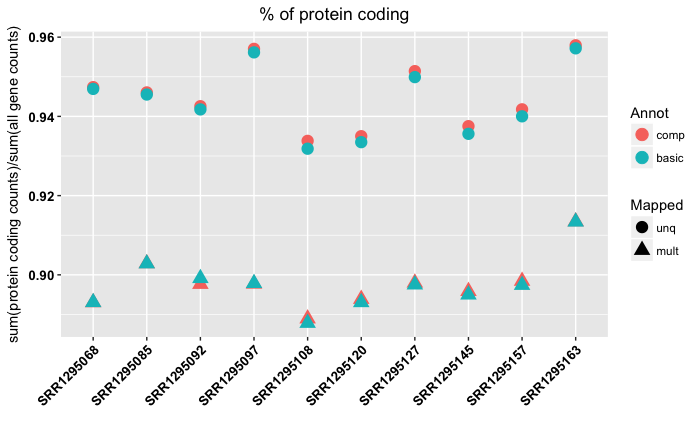

```r
x<-subset(output.per,Group == 'protein_coding')
p<-ggplot(data=melt(x),aes(x=variable,y=value,color=Annot,shape=Mapped))+geom_point(size=4)
p<-p+theme(axis.text.y = element_text(color='black',size=10,face='bold'),axis.text.x = element_text(color='black',size=10,face='bold',hjust=1,angle = 45))
p<-p+xlab(' ')+ylab("sum(protein coding counts)/sum(all gene counts)")+ggtitle(label = paste('% of protein coding',sep=''))
p<-p+theme(plot.title = element_text(hjust = 0.5))
p
```

```r
gencodes.coding<-x
```